# Reproducible Research: Peer Assessment 1

## Introduction:

This project analyzes data from a personal activity monitoring device. The device collects data at 5 minute intervals throughout the day for 2 months. The data file name is ‘activity.csv’ saved in the zip file ‘activity.zip’. The variables in the dataset are:  
- **steps:** Num of steps taken in a 5-min interval (missing vals are ‘NA’)  
- **date:** The date of the measurement (YYYY-MM-DD)  
- **interval:** Identifier for the 5-min interval (e.g., 0,5,10,15)

## Setup:

```r
knitr::opts_chunk$set(echo = TRUE)
library(readr)
library(ggplot2)
suppressPackageStartupMessages(library(dplyr))
```

## Loading and preprocessing the data

```r
data <- read_csv('activity.zip')
```

## What is mean total number of steps taken per day?

1.) Calculate the total number of steps taken per day

```r
nStepsByDate <- data %>%
    group_by(date) %>%
    summarize(sum(steps, na.rm=T))
names(nStepsByDate) <- c('date','nSteps')
```

2.) Plot a histogram of the total num of steps taken each day

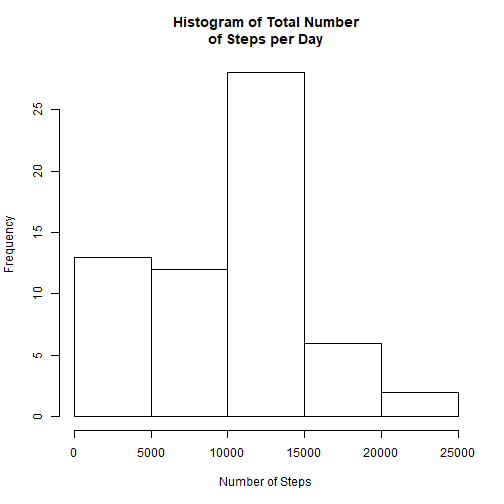

```r
hist(nStepsByDate$nSteps, main='Histogram of Total Number\nof Steps per Day',
     xlab='Number of Steps')
```

3.) Calculate the mean and median of the total num of steps per day

```r
meanStepsByDate <- mean(nStepsByDate$nSteps, na.rm=T)
medianStepsByDate <- median(nStepsByDate$nSteps, na.rm=T)
cat('  Mean = ', meanStepsByDate, '\nMedian = ', medianStepsByDate)
```

```
##   Mean =  9354.23
## Median =  10395
```

## What is the average daily activity pattern?

1.) Make a time series plot of nSteps (avg’ed across all days) vs the 5-min intervals

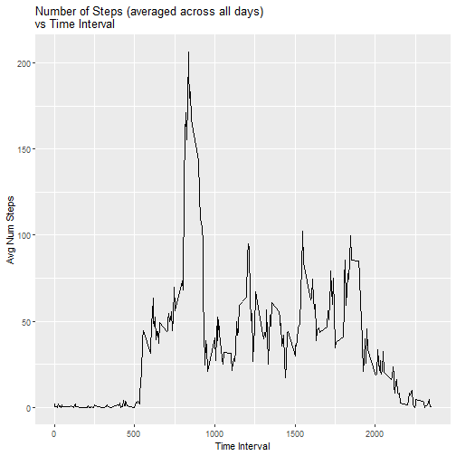

```r
nStepsByInterval <- data %>%
    group_by(interval) %>%
    summarize(avgNumSteps=mean(steps, na.rm=T)) %>%
    mutate(intNumSteps=as.integer(round(avgNumSteps)))
qplot(interval, avgNumSteps, data=nStepsByInterval,
      main='Number of Steps (averaged across all days)\nvs Time Interval',
      xlab='Time Interval', ylab='Avg Num Steps', geom='line')
```

2.) Which 5-min interval (on avg across all days) contains the max nDays?

```r
maxIntervalIndex <- with(nStepsByInterval, which(avgNumSteps==max(avgNumSteps)))
message(paste(capture.output({cat('\n5-min interval with max avg num of days:\n')
                             print(nStepsByInterval[maxIntervalIndex,])
                             }), collapse='\n'))
```

```
##
## 5-min interval with max avg num of days:
## # A tibble: 1 x 3
##   interval avgNumSteps intNumSteps
##      <int>       <dbl>       <int>
## 1      835        206.         206
```

- The average daily activity pattern follows the times series plot above.  
  – The average number of steps per 5-min time interval hovers around 50 steps.  
  – There are 3 increases to about 100 steps at approximately 1200hrs, 1530 hrs, and 1800hrs.  
  – There is a single spike of over 200 steps at 0835hrs.

## Imputing missing values

1.) Calculate the total number of missing values in the dataset

```r
nNA <- sum(is.na(data))
cat('Total number of NAs:', nNA)
```

```
## Total number of NAs: 2304
```

2.) Devise a strategy for filling in the missing data in the dataset  
– Replace all NAs with the mean for that 5-min interval. (These mean values were saved to nStepsByInterval)

3.) Create a new dataset that is equal to the original dataset but with the missing data filled in.

```r
# Copy dataset
newData <- data

# Get indices of NA entries
idx <- which(is.na(newData$steps))

# Replace NA step entries with the mean step entries found in nStepsByInterval
for (i in idx) {
    newData$steps[i] <- nStepsByInterval$intNumSteps[nStepsByInterval$interval==newData$interval[i]]
}

# Check result
cat('Total number of NAs in new dataset:', sum(is.na(newData)))
```

```
## Total number of NAs in new dataset: 0
```

4.) Redo the first part of the assignment (ignoring NAs) and compare to new data (with NAs filled in).

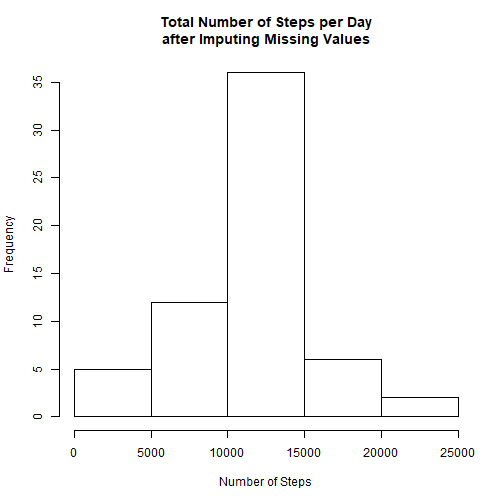

```r
# Calculate the total number of steps taken per day
nStepsByDate_new <- newData %>%
    group_by(date) %>%
    summarize(sum(steps, na.rm=T))
names(nStepsByDate_new) <- c('date','nSteps')

# Plot a histogram of the total num of steps taken each day
hist(nStepsByDate_new$nSteps, main='Total Number of Steps per Day\nafter Imputing Missing Values',
     xlab='Number of Steps')
```

```r
# Calculate the mean and median of the total num of steps per day
meanStepsByDate_new <- mean(nStepsByDate_new$nSteps, na.rm=T)
medianStepsByDate_new <- median(nStepsByDate_new$nSteps, na.rm=T)
cat('  Mean (after imputing) = ', meanStepsByDate_new, '\nMedian (after imputing) = ', medianStepsByDate_new)
```

```
##   Mean (after imputing) =  10765.64
## Median (after imputing) =  10762
```

- Is there a difference? What is the impact of imputing missing data on the estimates of the total daily number of steps?  
  – Both the mean and median of the new dataset are higher than those of the original dataset.  
  – The mean and median of the new dataset are much closer together than in the original dataset (almost identical).  
  – From visual inspection, the histogram of the new dataset is more normally distributed.

## Are there differences in activity patterns between weekdays and weekends?

1.) Create a new factor variable in the dataset with two levels indicating whether a given date is a weekday or a weekend.

```r
weekendNames <- c('Saturday','Sunday')
nStepsByInterval_new <- newData %>%
    mutate(dayCat=factor(weekdays(date) %in% weekendNames, labels=c('weekday','weekend'))) %>%
    group_by(dayCat,interval) %>%
    summarize(avgNumSteps=mean(steps, na.rm=T)) %>%
    mutate(intNumSteps=as.integer(round(avgNumSteps)))
```

2.) Make a panel plot containing time series plots of the number of steps, averaged across all weekday days or weekend days, vs the 5-minute time interval.

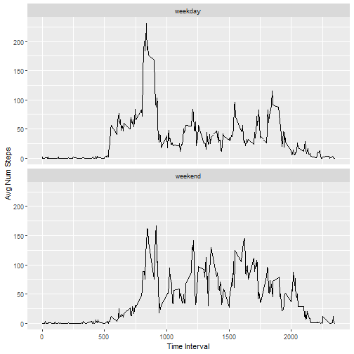

```r
qplot(interval, avgNumSteps, data=nStepsByInterval_new, xlab='Time Interval',
      ylab='Avg Num Steps', geom='line') + facet_wrap(~ dayCat,ncol=1)
```

- Are there differences between the weekdays and weekends?  
  – The spike at 0835hrs is still present in the weekday data. There is a double-peak at about the same time on the weekends, but not as large a number of steps.  
  – It appears that before approximately 1000hrs, the number of steps, averaged across all weekday days is higher.  
  – Above approximately 1000hrs, the number of steps, averaged across all weekend days is higher, until approx 2100hrs.  
  – Bottom line: People seem to walk a more consistent average number of steps throughout the day on the weekends, while there are a higher average number of steps before 0900hrs on weekdays.